# DS 303 HW1

Charles Yang 510 636 138

9/1/2021

## 1. Bias-Variance Decomposition

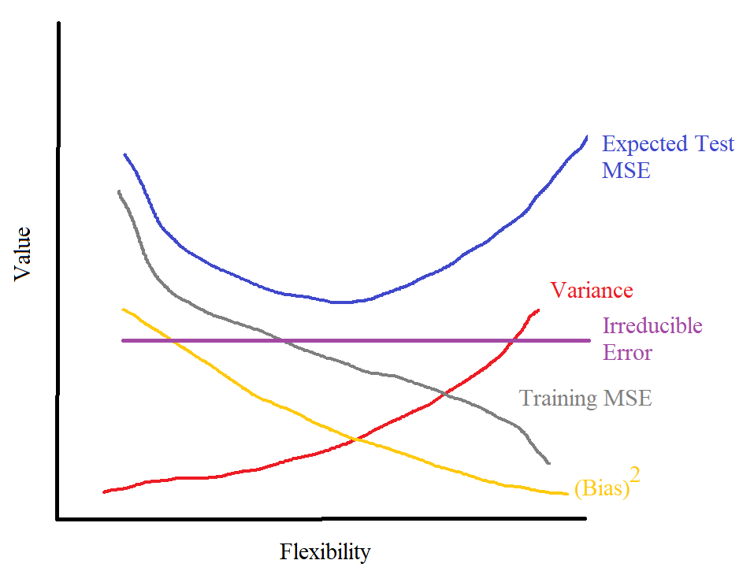

Model flexibility plays a key role in the reliability and accuracy of statistical models. As flexibility increases, variance increases because model that fits a particular sample will not work for other samples, resulting in wildly different models depending on the sample. Conversely, bias^2 decreases as flexibility increases. This is a direct result of the model being capabable of "bending" to the sample. Without flexibility, a model may not be able to capture all features in the data, resulting in high bias. Additionally, the more flexible a model is, the lower its training MSE because it fits the training set better. However, this may cause the expected test MSE to increase as some point, as the variance between the trained model and the true population model may result in great error. Finally, the irreducible error is, as it sounds, irreducible. It is caused by randomness in the population data as is usually impossible to quanitify.

```r
dim(Boston)
```

2a. How many rows and variables are in the data, and what does **lstat** represent?

There are 506 rows and 13 columns/variables. lstat is the percent of the population with a lower status.

```r
# rows
n = dim(Boston)[1]

# response var
y = Boston$crim

# design matrix
x = cbind(rep(1,n), Boston$lstat)

# least square estimators
xtx = t(x)%*%x
b = solve(xtx)%*%t(x)%*%y

# predicted values
yHat = x%*%b

model=lm(crim~lstat, data=Boston)
summary(model)
names(model)
```

[output not shown]

2b. Fit a simple linear regression model with lstat and crim

The estimated intercept and lstat coefficient is -3.33 and .549, respectively.

```r
ggplotRegression <- function (fit) {

require(ggplot2)

ggplot(fit$model, aes_string(x = names(fit$model)[2], y = names(fit$model)[1])) +
  geom_point() +
  stat_smooth(method = "lm", col = "red") +
  labs(title = paste("Slope =",signif(fit$coef[[2]], 5),
                     " P =",signif(summary(fit)$coef[2,4], 5)))
}

zn <- ggplotRegression(lm(formula=crim~zn, data= Boston))
indus <- ggplotRegression(lm(formula=crim~indus, data= Boston))
chas <- ggplotRegression(lm(formula=crim~chas, data= Boston))
nox <- ggplotRegression(lm(formula=crim~nox, data= Boston))
rm <- ggplotRegression(lm(formula=crim~rm, data= Boston))
age <- ggplotRegression(lm(formula=crim~age, data= Boston))
dis <- ggplotRegression(lm(formula=crim~dis, data= Boston))
rad <- ggplotRegression(lm(formula=crim~rad, data= Boston))
tax <- ggplotRegression(lm(formula=crim~tax, data= Boston))
ptratio <- ggplotRegression(lm(formula=crim~ptratio, data= Boston))
lstat <- ggplotRegression(lm(formula=crim~lstat, data= Boston))
medv <- ggplotRegression(lm(formula=crim~medv, data= Boston))
```

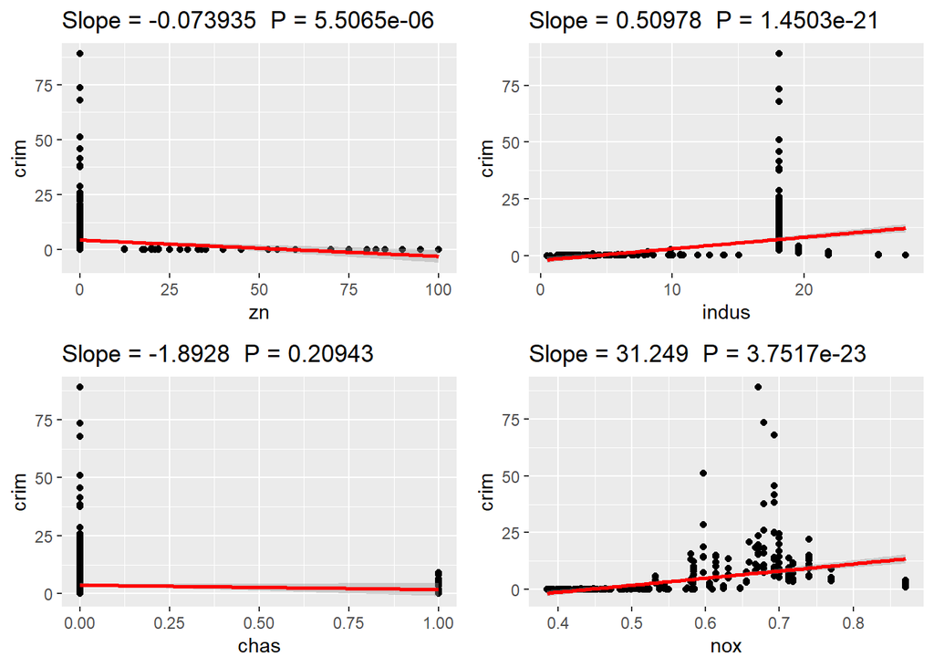

```r
plot_grid(zn, indus, chas, nox, rm, age, dis, rad, tax, ptratio, lstat, medv, tags = TRUE, ncol = 2, nrow = 2)
```

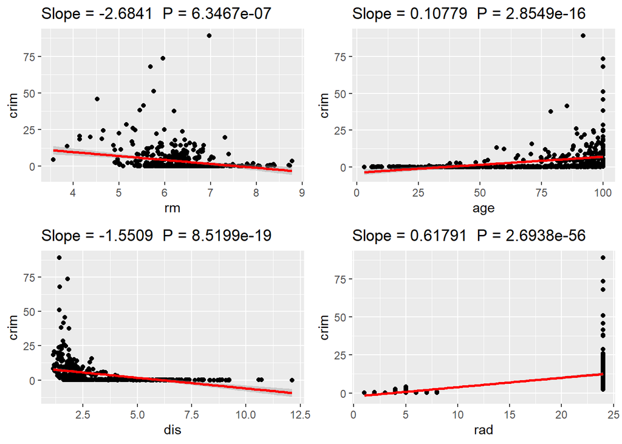

```r
plot_grid(rm, age, dis, rad, tags = TRUE, ncol = 2, nrow = 2)
```

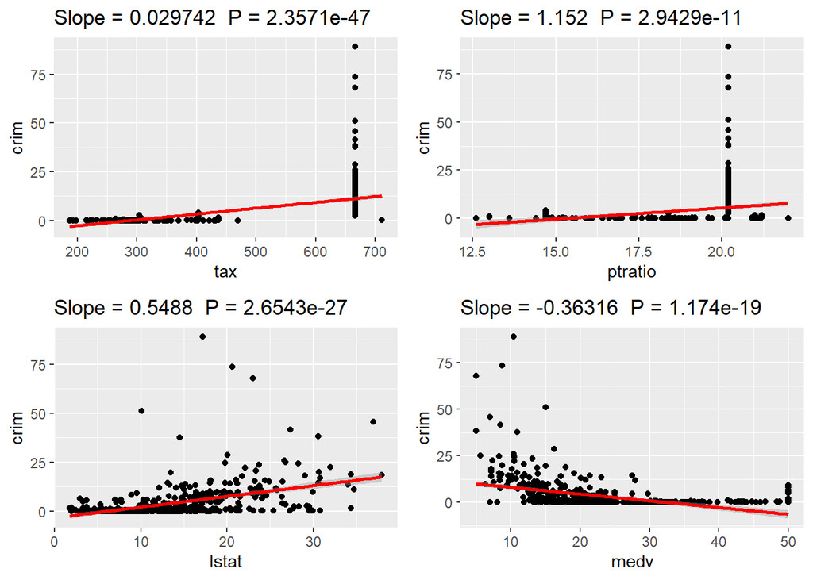

```r
plot_grid(tax, ptratio, lstat, medv, tags = TRUE, ncol = 2, nrow = 2)
```

2c. Fit SLR for each predictor in Boston. Which ones are statistifically significant?

All variables have a statistically significant relationship with crim except for "chas," with P = .209.  
zn, rm, dis, and medv have a negative relationship with crim, while ptratio, tax, lstat, age, rad, indus, nox have a positive relationship.  
Many variables are candidates for transforms due to unequal variance or visual nonlinearity

```r
summary(lm(crim~.,data=Boston))
```

```
##
## Call:
## lm(formula = crim ~ ., data = Boston)
##
## Residuals:
##    Min     1Q Median     3Q    Max
## -8.534 -2.248 -0.348  1.087 73.923
##
## Coefficients:
##               Estimate Std. Error t value Pr(>|t|)
## (Intercept) 13.7783938  7.0818258   1.946 0.052271 .
## zn           0.0457100  0.0187903   2.433 0.015344 *
## indus       -0.0583501  0.0836351  -0.698 0.485709
## chas        -0.8253776  1.1833963  -0.697 0.485841
## nox         -9.9575865  5.2898242  -1.882 0.060370 .
## rm           0.6289107  0.6070924   1.036 0.300738
## age         -0.0008483  0.0179482  -0.047 0.962323
## dis         -1.0122467  0.2824676  -3.584 0.000373 ***
## rad          0.6124653  0.0875358   6.997 8.59e-12 ***
## tax         -0.0037756  0.0051723  -0.730 0.465757
## ptratio     -0.3040728  0.1863598  -1.632 0.103393
## lstat        0.1388006  0.0757213   1.833 0.067398 .
## medv        -0.2200564  0.0598240  -3.678 0.000261 ***
## ---
## Signif. codes:  0 '***' 0.001 '**' 0.01 '*' 0.05 '.' 0.1 ' ' 1
##
## Residual standard error: 6.46 on 493 degrees of freedom
## Multiple R-squared:  0.4493, Adjusted R-squared:  0.4359
## F-statistic: 33.52 on 12 and 493 DF,  p-value: < 2.2e-16
```

2d. Fit MLR predicting crim with all predictors

Using a significance level of 0.05, We can reject the null hypothesis for zn, dis, rad, and medv. Honorable mentions include nox and lstat.

2e. How does the results in c differ from d?

Individually, most predictors have a significant relationship with crim. However, when fit together in a multiple regression, we find that many of them lose their significance. All predictors except for rad have drastically different coefficients between the models. This shows that relationships between variables change when considering more information.

[output not shown]

```r
set.seed(1)
train_index = sample(1:n,n/2,rep=FALSE)

train = Boston[train_index,]
test = Boston[-train_index,]

full_model = lm(crim~.,data=train)
MSE_train = mean((train$crim - full_model$fitted.values)^2)

predicted_values = predict(full_model,test)
MSE_test = mean((test$crim - predicted_values)^2)

print(MSE_train)
print(MSE_test)
```

2f. Do a train/test split and report MSE's

Train MSE is 42.49345 and test MSE is 41.19923.

```r
model = lm(crim~zn+indus+nox+dis+rad+ptratio+medv,data=train)
MSE_train = mean((train$crim - model$fitted.values)^2)

predicted_values = predict(model,test)
MSE_test = mean((test$crim - predicted_values)^2)

print(MSE_train)
print(MSE_test)
```

[output not shown]

2g. Fit MLR with zn, indux, nox, dis, rad, ptratio, and medv. Report new MSE's and note differences

New train MSE is 43.97466 and test MSE is 39.62763. The train MSE was higher, but the test MSE was lower. This is suprising, because we'd expect new data to be predicted less accurately. This is likely to be due to random chance, or the model itself is better.

3a. What are the true values for the Betas?

2, 3, and 5 respectively

```r
n = 100
x1 = seq(0,10,length.out=n) #generates 100 equally spaced values from 0 to 10.
x2 = runif(n) #generates 100 uniform values.

beta_0 = 2
beta_1 = 3
beta_2 = 5

error = rnorm(n, 0, 1)

y = beta_0 + beta_1*x1 + beta_2*log(x2) + error

print(y)
```

```
##   [1]  1.3721253 -9.9244082  1.0176305 -3.7344451 -8.5057683 -1.4082326
##   [7]  2.8712903 -2.3983667  2.3217102  2.6495584 -7.0874619  3.5644235
##  [13]  4.5518964  3.1337426  2.3260060  2.7870524  7.6404346 -2.1869005
##  [19] -0.6198313  3.1669717  2.4042349  8.6578589  0.1503532  5.8438655
##  [25]  4.9798881  6.4669266  8.4676032 11.2196503  0.7801346  4.2419163
##  [31] 10.3301021 10.0470842  1.7685598 11.4238732  2.4430571  3.7607903
##  [37] 14.2401532 10.0863058  3.7665085  7.3556425 11.7112459  7.6570035
##  [43]  9.2416564  5.8667518 12.3953888  9.8504238 15.8619290 16.8338618
##  [49] 13.9665802 15.9725304 10.8688315 17.1385608 -4.3260933 17.3453423
##  [55] 19.6565430 12.8210170 16.9348811 17.1114212 17.1658801 17.1104475
##  [61] 17.0960419 15.6025816 18.5786311 20.4920281 17.4728115 16.9501742
##  [67] 21.7236106 12.7187460 18.0431707 19.3543046 10.8542965 22.8602911
##  [73] 23.8304607 22.4315262 26.0633446 11.2200814 21.8301783 23.7448069
##  [79] 14.4527417 25.4014341 23.7099291 12.1002110 24.2448002 26.8364992
##  [85] 11.0935233 20.9807769 24.5674454 26.9592579 21.5283755 24.5479368
##  [91] 22.9606713 29.7740018 20.7381618 18.3848927 31.1178754 24.8416301
##  [97] 26.6053567 22.9974498 16.7673146 30.0764311
```

3b. Generate 100 values of y using the given equation.

See output above.

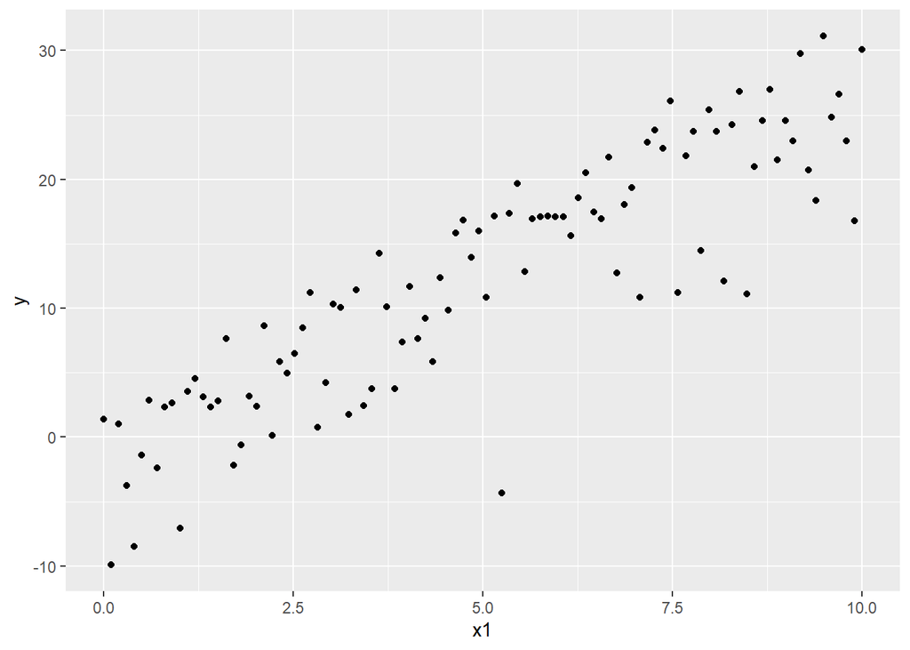

```r
ggplot(data=NULL, aes(x=x1, y=y)) + geom_point()
```

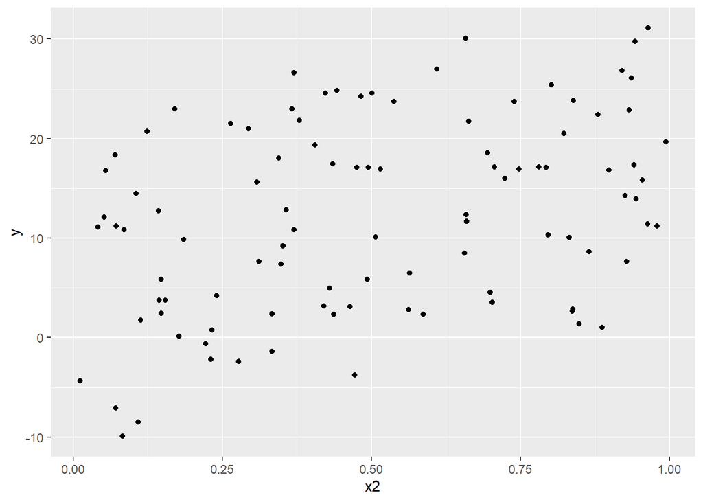

```r
ggplot(data=NULL, aes(x=x2, y=y)) + geom_point()
```

3c. Scatter plots of x1, x2, and y

The plot with x1 shows a relatively strong correlation with y. It's a relatively straight line with a few outliers.  
The plot with x2 appears to have a moderate/weaker correlation with y, and may or may not be a linear relationship. There are no obvious outliers.

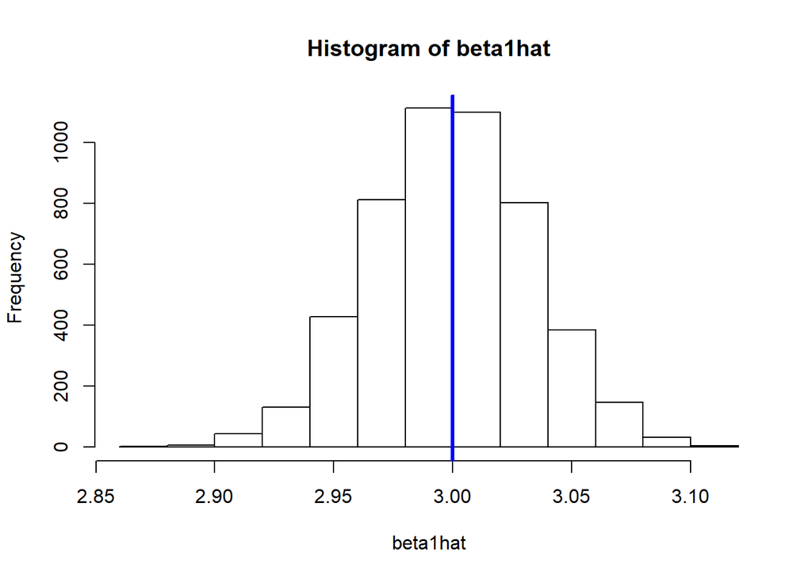

```r
B = 5000
beta1hat = rep(NA,B)
for(i in 1:B){
  error = rnorm(n,0,1)
  y = beta_0 + beta_1*x1 + error
  fit = lm(y~x1)
  beta1hat[i] = fit$coefficients[[2]]
}

hist(beta1hat)
abline(v=beta_1, col="blue", lwd=3)
```

3de. Show that B1 hat is an unbiased estimator of B1

The histogram is roughly normal and centered at B1, showing that the estimator is unbiased.

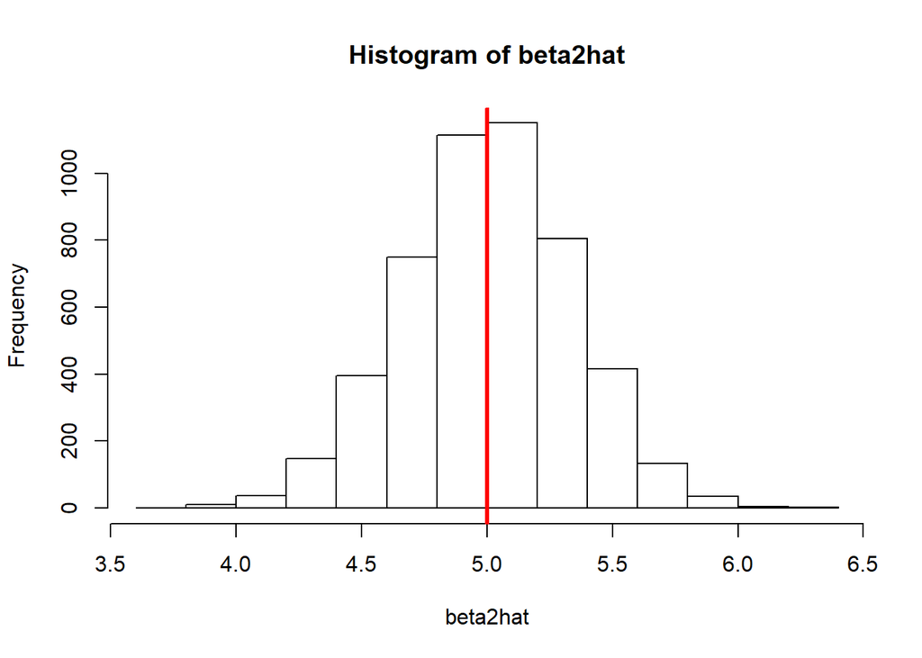

```r
B = 5000
beta2hat = rep(NA,B)
for(i in 1:B){
  error = rnorm(n,0,1)
  y = beta_0 + beta_2*x2 + error
  fit = lm(y~x2)
  beta2hat[i] = fit$coefficients[[2]]
}

hist(beta2hat)
abline(v=beta_2, col="red", lwd=3)
```

3fg. Show that B2 hat is an unbiased estimator of B2

The histogram is roughly normal and centered at B2, showing that the estimator is unbiased.